# ggplot2_CH2

### 2.6.2 Boxplots and Jittered Points

1. Three Techniques for Alleviating Overplotting (i.e. many points are plotted in the same location s.t. it’s difficult to see the dist):
1. Jittering `geom_jitter()`: adds a little random noise to the data which can help avoid overplotting.
1. Strength & Weakness: jittered plots show every pt but only work with relatively small datasets.
2. Boxplots `geom_boxplot()`: summarises the shape of the dist with a handful of summary statistics: min, max, first quartile (25th percentile; Q1), median (50th percentile; Q2), third quartile (75th percentile; Q3).
1. Strength & Weakness: boxplots summarise the bulk of the dist with only 5 numbers.

Interquartile Range (IQR)=Q3-Q1=$q_{n}(0.75)-q_{n}(0.25)$.

3. Violoin plots `geom_violin`: shows a compact representation of the “density” of the dist, highlighting the areas where more points are found.
1. Strength & Weakness: violin plots give the richest display but rely on the cal of a density estimate, which can be hard to interpret.

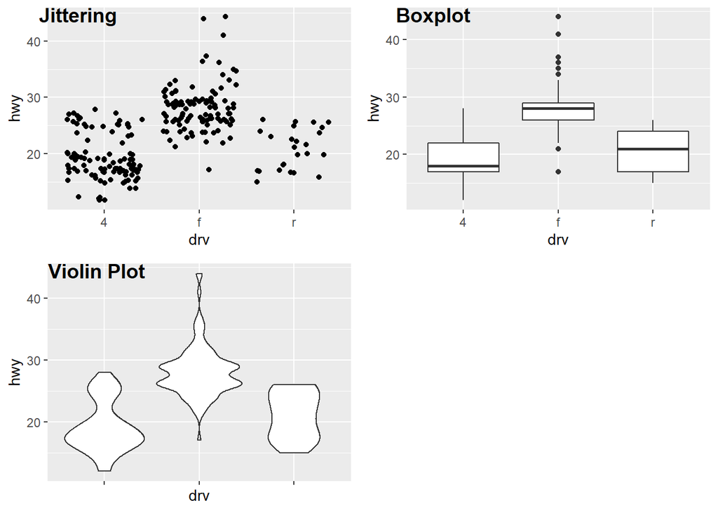

```r
jitter=ggplot(mpg, aes(drv, hwy))+geom_jitter()
box=ggplot(mpg, aes(drv, hwy))+geom_boxplot()
violin=ggplot(mpg, aes(drv, hwy))+geom_violin()


##NOTE: par(mfrow=c(x,y)) does NOT work for ggplot

ggarrange(jitter, box, violin+ rremove("x.text"),
          labels = c("Jittering", "Boxplot", "Violin Plot"),
          ncol = 2, nrow = 2)
```

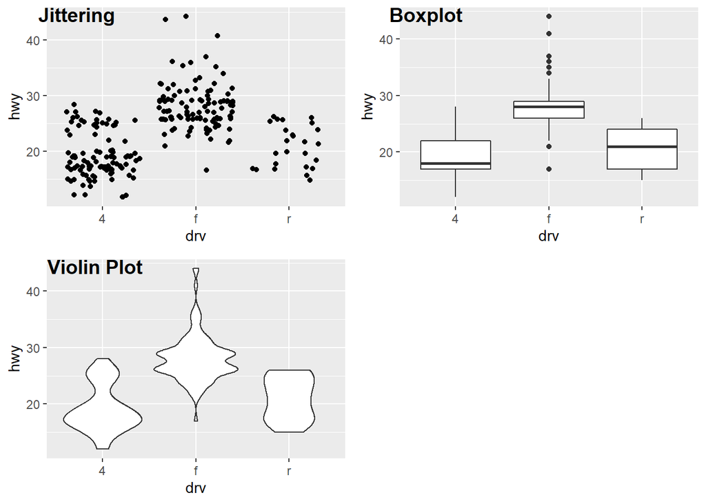

```r
# rremove: removes the object x.text for violin plot

ggarrange(jitter, box, violin,
          labels = c("Jittering", "Boxplot", "Violin Plot"),
          ncol = 2, nrow = 2)
```

2. For jittered points: `geom_jitter()` offers the same control over aesthetics as `geom_point()`: `size`, `color`, `shape`.
3. For `geom_boxplot()` and `geom_violin()`: can control the outline `color` or the internal `fill` color.